# (PISA 2012)

## by (Ammar Shaalan)

## Dataset Overview

> PISA is a survey of students' skills and knowledge as they approach the end of compulsory education. It is not a conventional school test. Rather than examining how well students have learned the school curriculum, it looks at how well prepared they are for life beyond school. Around 510,000 students in 65 economies took part in the PISA 2012 assessment of reading, mathematics and science representing about 28 million 15-year-olds globally. Of those economies, 44 took part in an assessment of creative problem solving and 18 in an assessment of financial literacy.

## Investigation Overview

> > iam interseted in seein the influence of gender,Parents' existence at home and a homogenous or heterogenous family background in student's perform in math, reading and science. Also iam carious about which countries have students with exceptionally high literacy scores and relation between three subjects

## (TOP 95th PERCENTILE IN Three Subjects)

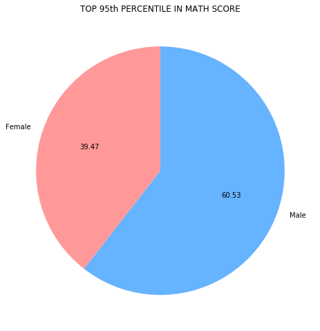

```python
plt.figure(figsize=[ 11.69, 8.27])
plt.pie(df_95math['Gender'].value_counts(), labels=df_95math['Gender'].value_counts().index,startangle=90,counterclock=False,autopct='%.2f',colors=color_set)
plt.title('TOP 95th PERCENTILE IN MATH SCORE');
```

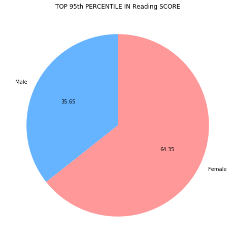

```python
plt.figure(figsize=[ 11.69, 8.27])
plt.pie(df_95reading['Gender'].value_counts(), labels=df_95reading['Gender'].value_counts().index,startangle=90,counterclock=False,autopct='%.2f',colors=color_set2)
plt.title('TOP 95th PERCENTILE IN Reading SCORE');
```

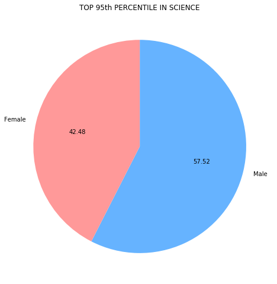

```python
plt.figure(figsize=[ 11.69, 8.27])
plt.pie(df_95science['Gender'].value_counts(), labels=df_95science['Gender'].value_counts().index,startangle=90,counterclock=False,autopct='%.2f',colors=color_set)
plt.title('TOP 95th PERCENTILE IN SCIENCE');
```

## (The effect of Parental companionship on Three subjects)

> On average, the highest scoring can be seen of students with both parents

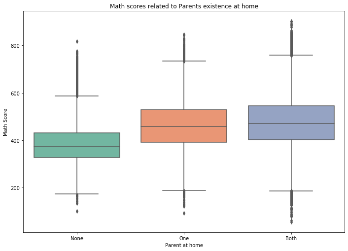

```python
plt.figure(figsize=[ 11.69, 8.27])
order = ['None', 'One', 'Both']
sb.boxplot(x = df['Parent at home'], y = df['Math Score'], palette = 'Set2', order=order)
plt.title('Math scores related to Parents existence at home');
```

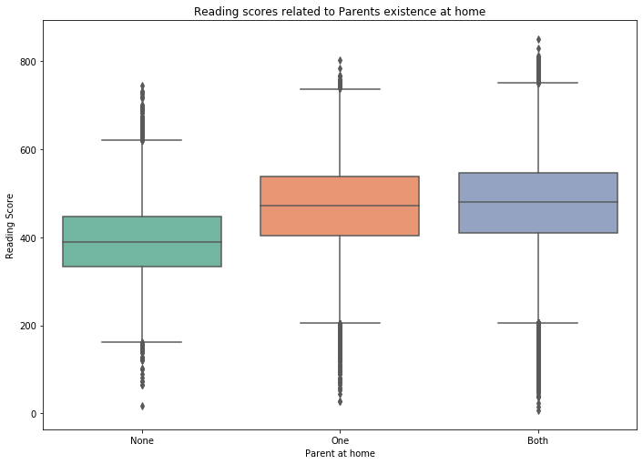

```python
plt.figure(figsize=[ 11.69, 8.27])
sb.boxplot(x = df['Parent at home'], y = df['Reading Score'], palette = 'Set2',order=order)
plt.title('Reading scores related to Parents existence at home');
```

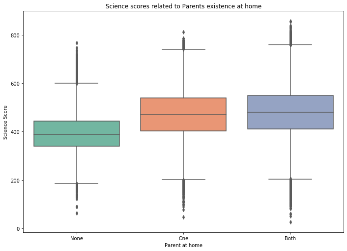

```python
plt.figure(figsize=[ 11.69, 8.27])
sb.boxplot(x = df['Parent at home'], y = df['Science Score'], palette = 'Set2', order=order);
plt.title('Science scores related to Parents existence at home');
```

## (Top 10 countries with the exceptional students)

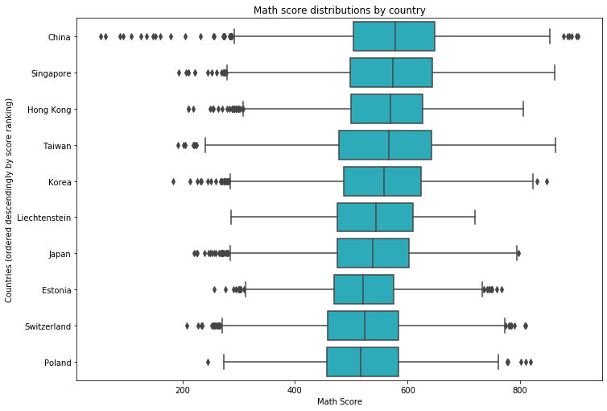

```python
plt.figure(figsize=[ 11.69, 8.27])
math_score_country_order = df.groupby('Country')['Math Score'].mean().sort_values(ascending = False).index[:10]
reading_score_country_order = df.groupby('Country')['Reading Score'].mean().sort_values(ascending = False).index[:10]
science_score_country_order = df.groupby('Country')['Science Score'].mean().sort_values(ascending = False).index[:10]
sb.boxplot(x = df['Math Score'], y = df['Country'], order = math_score_country_order, color = sb.color_palette()[9]);
plt.ylabel('Countries (ordered descendingly by score ranking)')
plt.title('Math score distributions by country');
```

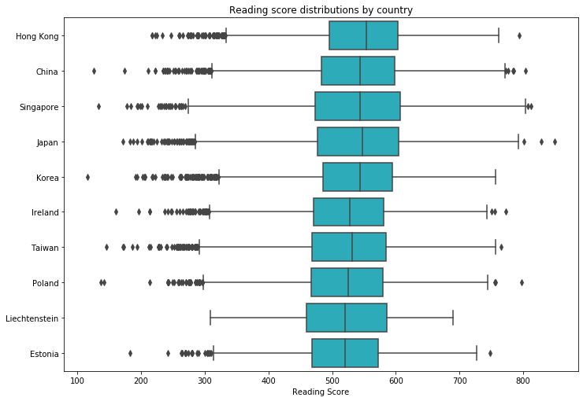

```python
plt.figure(figsize=[ 11.69, 8.27])
sb.boxplot(x = df['Reading Score'], y = df['Country'], order = reading_score_country_order, color = sb.color_palette()[9]);
plt.ylabel(''); # Remove the redundant label
plt.title('Reading score distributions by country');
```

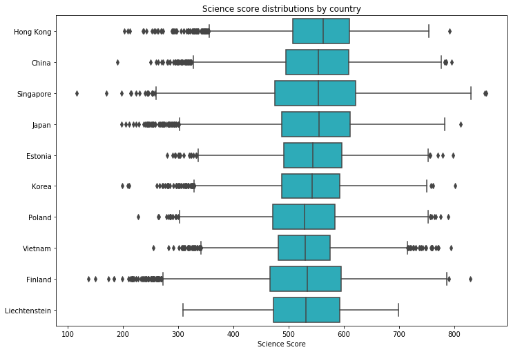

```python
plt.figure(figsize=[ 11.69, 8.27])
sb.boxplot(x = df['Science Score'], y = df['Country'], order = science_score_country_order, color = sb.color_palette()[9]);
plt.ylabel(''); # Remove the redundant label
plt.title('Science score distributions by country');
```

## (Family country combination)

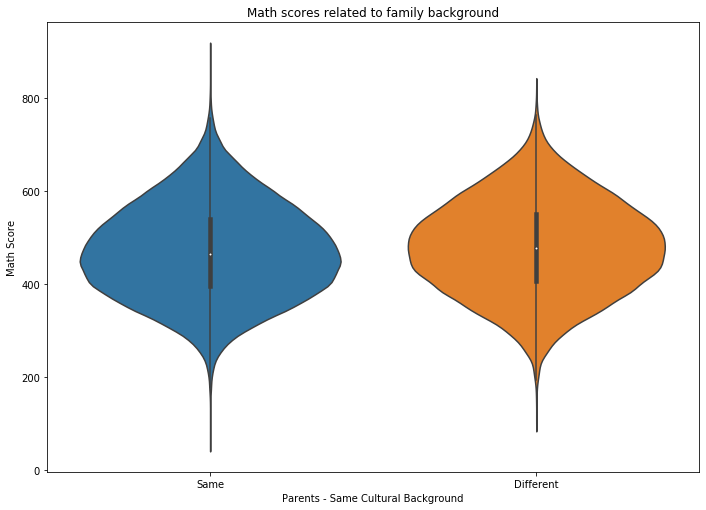

```python
plt.figure(figsize=[ 11.69, 8.27])
sb.violinplot(x = df['Parents - Same Cultural Background'], y = df['Math Score'])
plt.title('Math scores related to family background');
```

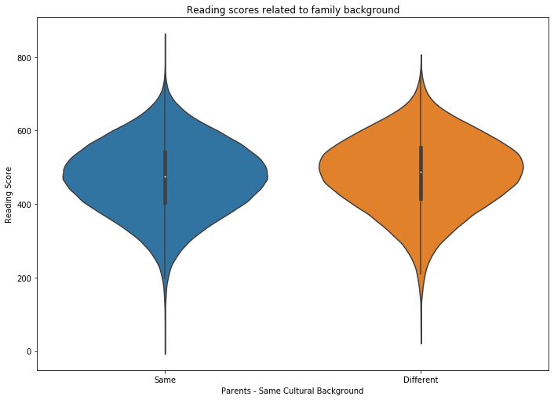

```python
plt.figure(figsize=[ 11.69, 8.27])
sb.violinplot(x = df['Parents - Same Cultural Background'], y = df['Reading Score'])
plt.title('Reading scores related to family background');
```

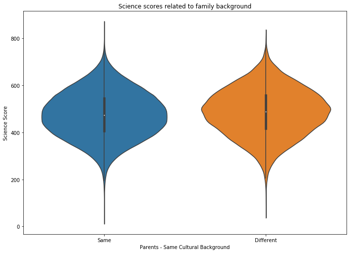

```python
plt.figure(figsize=[ 11.69, 8.27])
sb.violinplot(x = df['Parents - Same Cultural Background'], y = df['Science Score']);
plt.title('Science scores related to family background');
```

In general, students' learning is closely related to each subject. From the following correlation diagram, it can be seen that there is a high positive correlation between different subjects.

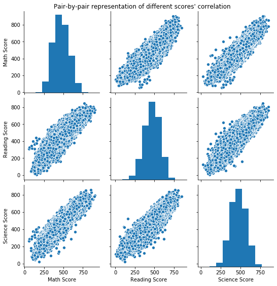

```python
grid = sb.pairplot(data = df, vars=["Math Score", "Reading Score", "Science Score"]);
grid.fig.suptitle("Pair-by-pair representation of different scores' correlation", y = 1.02);
```

## Conclusions

Exploring from the original problem, we got several conclusions as follows:

Students with their parents will have better study The performance of girls in reading is better than that of boys. But the performance of boys in mathematics and science is better. In the PISA test, the scores of Asian countries seem to be slightly higher. Finally, there is a very strong and positive correlation between any pair of the three variables representing the score of the three subjects.